# Bent Spring 2006

R. G. Cronce

12/19/2019

# Bent Brain Ticklers, Spring 2006

The prequel has a plea to stop using the computer and start exercising the gray cells.

## Problem 1

```
A 10-digit number consists of two
4s, two 3s, two 2s, two 1s, and two 0s.
The 4s are separated by four digits,
the 3s by three digits, the 2s by two
digits, the 1s by one digit, and the 0s
by no digits. What are the smallest
and largest such numbers? Leading
zeros are not allowed.

-- Adapted from The Mathematics Teacher
```

Solution:

```
    1 2 1 4 2 3 0 0 4 3  --> smallest number
    4 1 3 1 2 4 3 2 0 0  --> largest number


These are like rigid puzzle pieces that must
fit together.  The pieces are:

    4 - - - - 4
    3 - - - 3
    2 - - 2
    1 - 1
    0 0

In attempting to make the largest number we will
start with 4.  In this case, the next digit can
not be 3 since the trailing 3 will fall on top of the
trailing 4.  Let's try a 2 instead:

    4 2 - - 2 4

    3 - - - 3
    1 - 1
    0 0

Unfortunately, there is no way forward.  The 00 could
fill the gap but then the 3---3 makes for an 11 digit
number.

Try 41:

    4 1 - 1 - 4

    3 - - - 3
    2 - - 2
    0 0

The 3 can fill the first empty slot:

    4 1 3 1 - 4 3
    2 - - 2
```

[output cut: 17 more lines]

```
    4 - - - - 4
    3 - - - 3
    0 0

The empty slot can not be 0 or a 3.  If it is 3 then the
string starting with 4 will result in 11 digits. So:

    1 2 1 4 2 - - - 4

    3 - - - 3
    0 0

Filling in the final digits:

    1 2 1 4 2 3 0 0 4 3 --> smallest number
```

## Problem 2

```
Lay out a line of length 2 along
the x-axis of a coordinate system,
with the center of the line at the
origin. Above this line, construct an
isosceles triangle with the line as a
base and base angles of 75 deg. Below
the line construct another isosceles
triangle (with its vertex pointing
down) with the line as a base and
base angles of 45 deg. What is the radius
of the inscribed circle of the lanceolate
figure formed by the sides of the
two triangles, and where is its center
(distance from the origin along the yaxis)?
Express your answer exactly
in terms of surds.

-- Technology Review
```

Solution: need a picture to visualize this:

```
Symbolically:

    y0 = (2*sin(75)-sqrt(2))/(2*cos(75)+sqrt(2))
       = 2-sqrt(3)

    d  = sqrt(2)*(sin(75)+cos(75))/(sqrt(2)+2*cos(75))
       = (3-sqrt(3))/sqrt(2)

Numerically:
    y0 = 0.2679492
    d = radius = 0.8965755


Height/1 = tan(theta)
Height = tan(theta)

Upper triangle has height of tan(75)
Bottom triangle has height of -tan(45)
```

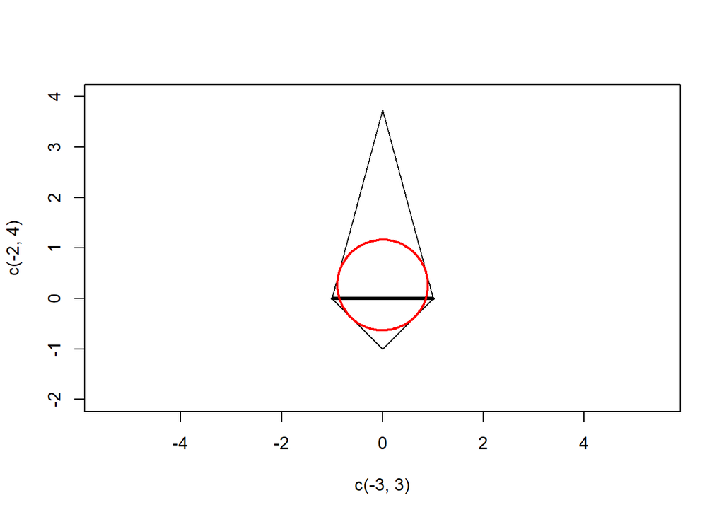

```r
# Make an empty region to plot on
plot(c(-3,3),c(-2,4),type='n',asp=1)

# Base of the triangle
lines(c(-1,1),c(0,0),lwd=3)

# Upward pointing triangle
y_top=tan(75*pi/180)
lines(c(-1,0),c(0,y_top))
lines(c(1,0),c(0,y_top))

# Downward pointing triangle
y_bot=tan(45*pi/180)
lines(c(-1,0),c(0,-y_bot))
lines(c(1,0),c(0,-y_bot))

# Draw in the circle after solving the problem
if (T) {
    x0=0
    y0 = 2-sqrt(3)
    r = (3-sqrt(3))/sqrt(2)

    theta=seq(0,2*pi,length=100)
    x=x0+r*cos(theta)
    y=y0+r*sin(theta)
    polygon(x,y,border='red',lwd=2)
}
```

Need to find a point that is equi-distance from the long sides of the two triangles. By symmetry this is somewhere along the y-axis. The distance to the lines will then be the radius of the inscribed circle.

Given a point: x0,y0 and a line y=m*x+b what is the distance from the point to the line?

[Wikipedia has the answer](https://en.wikipedia.org/wiki/Distance_from_a_point_to_a_line)

```
Turns out this is a bit ugly.

if a*x+b*y+c = 0 then the distance to (x0,y0) is:

    d = |a*x0+b*y0+c|/sqrt(a^2+b^2)

We know the center of the circle is at (0,y0):

For the upper triangle, left side:

    y = tan(75)*x + tan(75) --> tan(75)*x + (-1)*y + tan(75) = 0

    d = |tan(75)*0 + (-1)*y0 + tan(75)|/sqrt(tan(75)^2+1)

      = (3.732051 - y0) / 3.863703

For the lower triangle, left side:

    y = -tan(45)*x - tan(45) --> tan(45)*x + (1)*y + tan(45) = 0

    d = |tan(45)*0 + (1)*y0 + tan(45)|/sqrt(tan(45)+1)

      = (1+y0) / sqrt(2)

These two must be the same:

    (3.732051 - y0) / 3.863703 = (1+y0) / sqrt(2)

    y0 = (3.732051/3.863703-1/sqrt(2))/(1/sqrt(2)+1/3.863703)
       = 0.2679493

The radius of the circle is just the distance to the line:

    d = radius = 0.8965756

Doing this symbolically instead:

    y0 = (2*sin(75)-sqrt(2))/(2*cos(75)+sqrt(2))
       = 2-sqrt(3)

    d  = (1+2-sqrt(3))/sqrt(2)
       = (3-sqrt(3))/sqrt(2)
```

## Problem 3

```
A and B each put 10 coins in the
pot. A then takes a coin from the pot
and tosses it, while B calls heads or
tails. If B's call is correct, he takes
the coin and keeps it; otherwise, A
keeps the coin. B then takes a coin
from the remaining pot and tosses it
while A calls heads or tails. The play
continues in this way until one player
has accumulated 10 coins, whereupon
he wins the game and takes all the
coins remaining in the pot. At one
point in the play, A has six coins,
while B has only four. What is A's
probability of winning? When the
situation occurs in a game such that
one player has won six coins while
his opponent has won four coins,
what is the expected value of the
winnings (net number of coins) of the
player with six coins?

-- Attributed to the Chevalier de Mere,
a 17th century gambler
```

Solution:

```
The pot initially has 20 coins.

When A=6, B=4 there are 10 coins remaining.

What is the probability that A reaches 10 first?

We will try Monte-Carlo and then think about analytics:
```

```r
ntrials=100000

win=0
win_sum=0
for (trial in 1:ntrials) {
    A=6
    B=4
    while(T) {
        s=sample(c(0,1),1)
        if (s==0) {
            A=A+1
            if (A==10) {
                win=win+1
                win_sum=win_sum+(20-A-B)
                break
            }
        } else {
            B=B+1
            if (B==10) {
                break
            }
        }
    }
}
print(paste0("Pr(win) = ",win/ntrials))
```

```
## [1] "Pr(win) = 0.74843"
```

```r
print(paste0("Mean(winnings) = ",win_sum/win))
```

```
## [1] "Mean(winnings) = 3.32258193819061"
```

Monte-Carlo results:

[output not shown]

Note that these winnings only occur if A actually wins. The times when A does not win the winning are 0. Weighting this gives:

[output not shown]

According to the Bent this should be 2.000. The Bent does everything using combinatorics.

## Problem 4

```
You have two two-liter bottles,
one (marked W) containing one liter
of pure water and one (marked A)
containing one liter of pure alcohol.
The two things you can do are to
pour liquid from either bottle down
the drain or pour liquid from one
bottle into the other, but you must
always keep at least one liter of liquid
in bottle A. What is the minimum
alcohol concentration that can be
achieved in bottle A? Assume that
there is no volume change on mixing
water and alcohol.

-- Daryl Cooper
```

Solution:

```
If we add 1/m L Water to Alcohol and then dump the
excess A+W back to 1L each time:

In the limit as m->infinity this approaches exp(-1).


The obvious answer is you can get 50% by pouring
all the water into the alcohol.  Of course this
is quite boring.

What if we try some things:

1. Add half the water to alcohol
   Throw away 1/3 of the A+W mixture
   Remaining alcohol = 2/3
   Add the remainder of the water:
        Alcohol concentration =  (2/3)/(1+1/2) = (2/3) / (3/2) = 4/9 < 1/2

2. Add 1/4L the water to the alcohol
   Throw away 1/5 of the A+W mixture
   Remaining alcohol = 4/5

   Add 1/4L water
   throw away 1/5 of the mixture
   Remaining alcohol = (4/5)^2

   then (4/5)^3 finally (4/5)^4 = 0.4096

 ...

 m=integer

 In general, add 1/m L water to alcohol
 Remove 1/m L of the mixture --> remaining is m/(m+1)
 ...
 repeat this m times
 ...
 Final result = (m/(m+1))**m

In the limit as m->infinity this approaches exp(-1)
```

## Problem 5

```
A modern aluminum sculpture
consists of a hollow cylinder that is
capped on one end by a solid hemisphere.
The cylinder has an outer
diameter of 100 cm and thickness of
1 cm, and the hemisphere has the
same diameter as the outside of the
cylinder. If, on a level surface, the
sculpture balances in stable equilibrium
at any point on its hemispherical
surface, how long is the cylinder, and
what is the minimum ceiling height
in the museum to permit the sculpture
to assume any stable position?

-- R. Wilson Rowland, MD B '51
```

Solution:

[output not shown]

## Bonus

```
Select three points at random
from within a right circular cone
of altitude h. What is the expected
value of the distance of the closest
point from the base?

-- John W. Langhaar, PA A '33
```

Solution:

```
I think they multiplied the derived probability by three to
account for the fact that there are three possible points that
might be the lowest.  It is the only thing that makes sense.

Given a height, y, above the base of the cone, the volume above
that height is:

    Vtop = 1/3*pi*(R*y/h)**2*(h-y)

The total volume is:

    V = 1/3*pi*R**2*h

The ratio is the probability of picking a point in the top volume:

    Pr = Vtop/V = (y/h)**2*(h-y) / h

Given an arbitrary set of altitudes: y1, y2, y3

What is the probabiity that y2>y1 and y3>y1?

    YUCK!
```

Here is what they did in the Bent:

```
Consider a (differential) circular disk at a height h above the base.

The probability of a point being in this disk is:

    Pr = pi*(R*(h-y)/h)**2*dy / (1/3*pi*R**2*h)
       = 3*(h-y)**2/h**3

So -- the probability of being between y and the top of the cone is:

    Pr = integrate(3*(h-tau)**2/h**3,(tau,y,h))
    Pr =  (h-y)**3 / h**3
       =  (1-y/h)**3

The probability of two points being higher:

    Pr = (1-y/h)**6

Total probability is then:

    Pr(point is in the disk)*Pr(both other points are higher)

    = 3*(h-y)**2/h**3 * (1-y/h)**6

The expected value is:

    integrate(y * 3*(h-y)**2/h**3 * (1-y/h)**6, (y,0,h))

    = h/30

This does NOT match the result from the Bent: h/10

I am going to hand-wave that there are three points so this Pr applies
to all three.  The total probability is then:

    3*Pr = h/10

The Bent makes the following derivation:

differential slice of the cone with diameter = x at distance of y from base

Pr(in slice) = pi*(x/2)**2*dy / (1/3*pi*(D/2)**2*h)
             = 3*x**2/ (D**2*h) * dy

Also: x/D = (h-y)/h --> x=D*(h-y)/h = D*(1-y/h)

Pr (point being above y) = x**2 * (h-y)/(D**2 * h) (ratio of two cones)

    = (1-y/h)**3 (substitute for x = f(y))

For two points: Pr = (1-y/h)**6

Expected value is then (presented without any explanation):

    E = (9/D**2) * integrate(x**2*y*(1-y/h)**6,(y,0,h))

I understand Pr(in slice) = 3*x**2/(D**2*h)

I would write this based on results above as:

    integrate(3*x**2/(D**2*h)*y*(1-y/h)**6,(y,0,h))

    = integrate(3/h * (x/D) **2 * y * (1-y/h)**6, (y,0,h))
    = integrate(3/h * (1-y/h)**2 * y * (1-y/h)**6, (y,0,h))
    = integrate(3/h * y * (1-y/h)**8,(y,0,h))
    = h/30

    which is the same result I got.

I think they snuck in the factor of 3 without any explanation.
```

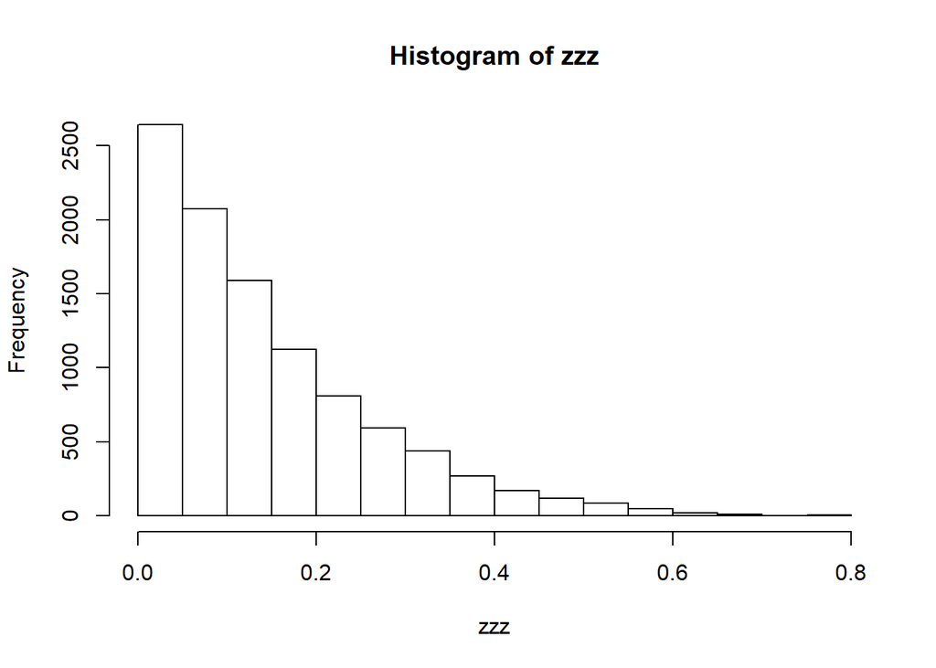

```r
ntrials=10000

# Sample random points in x,y until we get a point inside the cone
# Do this until we get 3 points.

zzz=c()
for (trials in 1:ntrials) {
    # Get three points
    x=c()
    y=c()
    n=0
    while(T) {
        x0=runif(1); y0=runif(1)
        if ((1-y0)>=x0) { x=c(x,x0); y=c(y,y0); n=n+1}
        if (n==3) { break }
    }
    zzz=c(zzz,min(y))
}
hist(zzz)
```

```r
print(summary(zzz))
```

```
##      Min.   1st Qu.    Median      Mean   3rd Qu.      Max.
## 0.0001065 0.0470770 0.1078851 0.1418790 0.2048475 0.7824307
```

So – what the heck does expected value really mean?

## Double Bonus

```
For many years,
the Roman Catholic church used the
Julian calendar, which has a leap year
every year that is divisible by four,
making the average calendar year
longer than the sidereal year and
causing the date of the first day of
spring to change gradually. To correct
this, Pope Gregory decreed that
Thursday, October 4, 1582, would be
followed by Friday, October 15. He
also declared that years divisible
by 100 would be leap years only if
divisible by 400. For any year since
1582, if one printed two 12-month
calendars, one Julian and the other
Gregorian, with dates for the days
of the month, at least some of the
dates would not fall on the same day
of the week. What is the first year
for which each day of each month will
fall on the same day of the week for
both calendars?

-- Colin Singleton in New Scientist
```

TODO

I don’t really care but the Bent explanation is that the two calendars will be in sync iff the number of days between them is divisible by 7.

They were forced 10 days apart in 1582.

The two calendars are the same except in years that are divisible by 100 (by not 400). This occurs in 1700,1800,1900, and 2100 to make the total number of days different = 14. So, in the first non-leap year (2101) the two will be in sync and stay there until 2200.